# “Homework 3”

Ballesteros, Mele

### Exercise I: Generate samples from a DAG

Consider the following (Bayesian) model in DAG format

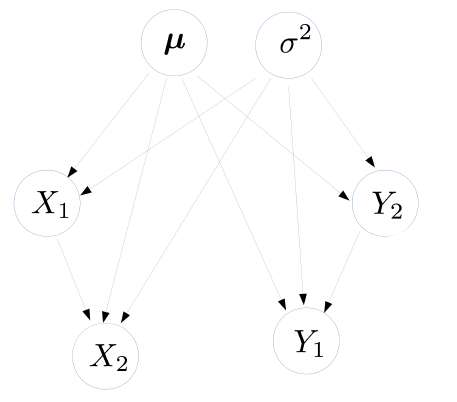

where, conditionally on $\mu= [\mu_1, \mu_2]$ and $\sigma^2$, we assume that:

- $X = [X_1,X_2]^T \sim N_2(\mu,\sigma^2 I_2)$
- $Y = [Y_1,Y_2]^T \sim N_2(\mu,\sigma^2 I_2)$

**1)**
The joint distribution corrinsponding to this DAG is:
$$P(\mu,\sigma^2,X_1,X_2,Y_1,Y_2)=P(\mu)\cdot P(\sigma^2)\cdot P(X_1|\mu,\sigma^2) \cdot P(X_2 |X_1,\mu,\sigma^2)\\
\cdot P(Y_2|\mu,\sigma^2) \cdot P(Y_1 |Y_2,\mu,\sigma^2)$$

where :

- $P(X_1|\mu,\sigma^2)$ is a marginal distribution of $X$ and so is a Gaussian with parameters $\mu_1$ and $\sigma$
- $P(Y_2|\mu,\sigma^2)$ is a marginal distribution of $Y$ and so is a Gaussian with parameters $\mu_2$ and $\sigma$
- $P(X_2 |X_1,\mu,\sigma^2)$ is a conditional distribution of $X$ and so is a Gaussian with parameters $\mu_{2|1}$ and $\Sigma_{2|1}$
- $P(Y_1 |Y_2,\mu,\sigma^2)$ is a conditional distribution of $Y$ and so is a Gaussian with parameters $\mu_{1|2}$ and $\Sigma_{1|2}$

Considering that:
$$\mu_{1|2}=\mu_1 + \Sigma_{12}\Sigma_{22}^{-1}(x_2-\mu_2)$$
$$\Sigma_{1|2}= \Lambda_{11}^{-1}= \Sigma_{11} -\Sigma_{12}\Sigma_{22}^{-1}\Sigma_{21}$$

And since that $\Sigma_{12}$ and $\Sigma_{21}$ in our case are equal to $0$:

- $\mu_{2|1}=\mu_2$
- $\Sigma_{2|1}=\Sigma_{22}=\sigma$
- $\mu_{1|2}=\mu_1$
- $\Sigma_{1|2}=\Sigma_{11}=\sigma$

Therefore:
$$P(DAG)=P(\mu)\cdot P(\sigma)\cdot N_{x_1}(\mu_1,\sigma)\cdot N_{x_2}(\mu_2,\sigma)\cdot N_{y_1}(\mu_1,\sigma)\cdot N_{y_ 2}(\mu_2,\sigma)$$

and if $\mu$ and $\sigma$ distributions are Normal we get approximately a 7 dimensionality Multivariate Normal Distribution.

**2)**  
Choosing a bivariate normal distribution for $\mu$ and a univariate normal distribution for $\sigma$, we can simulate a sample of n=10000 random vectors from the joint distribution, in this way:

```r
library(mnormt)

# Simulation size
n= 1e4

# This (M x 7) matrix will store the samples from the joint
sim.samp <- matrix(NA, nrow = M, ncol = 8)
colnames(sim.samp) <- c("sigma1","sigma2","tetha","x1","x2","y1","y2", "DAG")

#Main loop
varcov<- matrix(c(1,0,0,1),2,2)
for (i in 1:n){
  sim.samp[i,1:2]<- rmnorm(1,c(2,7), varcov)
  sim.samp[i,3]<- abs(rnorm(1))
  sim.samp[i,4] <- rnorm(1, mean = sim.samp[i,1], sd = sim.samp[i,3])
  sim.samp[i,5] <- rnorm(1, mean = sim.samp[i,2], sd = sim.samp[i,3])
  sim.samp[i,6] <- rnorm(1, mean = sim.samp[i,1], sd = sim.samp[i,3])
  sim.samp[i,7] <- rnorm(1, mean = sim.samp[i,2], sd = sim.samp[i,3])
  sim.samp[i,8] <- prod(sim.samp[i,1:7])
}
```

**3)**  
There are the empirical cumulative distribution function plots of $x_1$ and $x_2$:

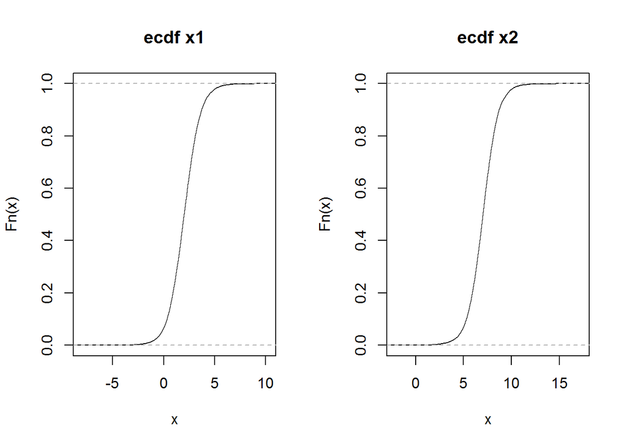

As we can see from the plots, both components of $X$ are univariate Normal Distribuited; infact $X_1\sim N(2,2)$ and $X_2 \sim N(7,2)$

## Last homework

**10.3**  
Let U and V be the two random variables from the table. We have seen that U and V are dependent with joint probability distribution

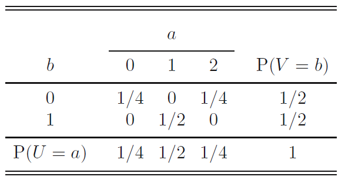

Determine the covariance $Cov(U, V)$ and the correlation coefficient $\rho(U, V )$

**- answer**

We have that:
$$E(U)=1 \quad E(V)=\frac{1}{2} \quad E(UV)=\frac{1}{2}$$
so, must be:
$$Cov(U,V)=0 \quad and \quad \rho(U,V)=0$$

**10.15**  
In Figure three plots are displayed. For each plot we carried out a simulation in which we generated 500 realizations of a pair of random variables $(X,Y)$. We have chosen three different joint distributions of $X$ and $Y$.

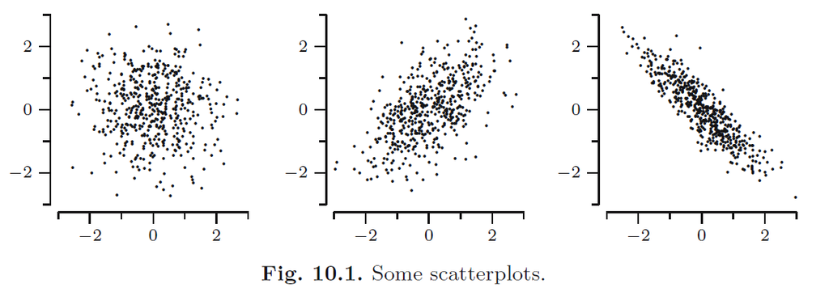

1. Indicate for each plot whether it corresponds to random variables $X$ and $Y$ that are positively correlated, negatively correlated, or uncorrelated.
2. Which plot corresponds to random variables $X$ and $Y$ for which $|\rho(X,Y)|$ is maximal?

**- answer**

The First plot indicates that for the first sample of $X$ and $Y$ are uncorrelated, the second plot suggest that the second sample is positively correlated, while the third shows a negatively correlated sample.

The last figure has a more concetrated dispensation, so it’s suppose to be the one with largest $|\rho(X,Y)|$.

**Part II 3**  
Let $\Omega$ be the sample space and $A$ and $B$ two events in $\Omega$. Although we did not say this explicitly, we can define covariance and correlation for events too. The trick is to attach to each event a suitable random variable, and then apply the definition. The obvious choice for these random variable are indicator functions, that is, given an event $A \in \Omega$, define

$$1_A \begin{cases} 1 & \mbox{if the event } A \mbox{ occurs} \\ 0 & \mbox{otherwise, that is, if } A^c \mbox{ occurs} \end{cases}$$

Since $A$ is random, $1_A$ is also random. Based on this little trick, answer the following questions:

1. What is the distribution of the random variable $Y=1_A$ ?
2. Based on the previous answer, show that:
   $$Cov(A,B)=P(A\cap B) - P(A)\cdot P(B)$$
3. Give a formula for the correlation coefficient $\rho(A,B)$.

**- answer**

The evident distribution for these random variables are **Bernoulli** distribution, with probability equal to $p_A$ and $p_B$, therefore:

- $E(A)=p_A$ and $Var(A)=p_A(1-p_A)$
- $E(B)=p_B$ and $Var(B)=p_B(1-p_B)$

Since:
$$Cov(A,B)= E(AB) - E(A)E(B)$$

we must compute $E(AB)$ that is equal to $P(A \cap B)$, so:
$$Cov(AB)= P(A \cap B) - P(A)P(P)$$

and
$$\rho(AB)=\frac{Cov(AB)}{(p_a(1-p_A)p_B(1-p_B))^{-\frac{1}{2}}}$$